# GDP per capita analysis

Ajeet Parmar

7/9/2020

In our current world, developing nations are often pictured far from reality: Many forms of media display developing countries as places of famine, human rights abuses, and endless conflict. However, in many places, this is far from the truth. Due to increased development in regions such as sub-Saharan Africa and Southeast Asia, many countries have experienced significant growth, making the old dogma of developing countries irrelevant. In this article, I examine gdp per capita comparisons between Western countries (ex: the US, Sweden, Germany, etc.) and developing countries. I also include transitional countries: Brazil, Russia, India, China, and South Africa since these countries are generally more developed than their developing counterparts.

This first graph compares the Gdp per capita of these groups in 1960:

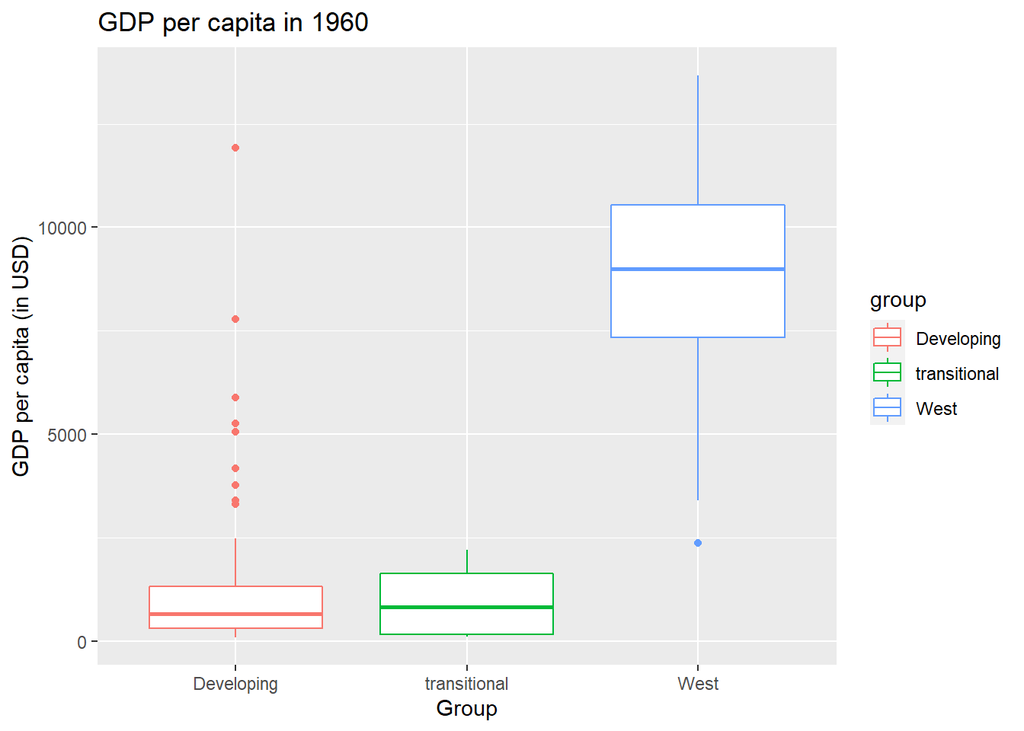

In this first graph, you can see that the west has a significantly higher GDP per capita than the transitional and developing countries. Since many of these countries were either relatively new nations or became independent in 1960, the preconcieved notion regarding developing countries makes sense since these countries lacked the industrial base to make progress due to being former or current colonies at that time.Similarly, these countries were mostly agricultural economies so these countries would not have large economies compared to other developed nations at that time. However, in the transitional countries, some industrial progress was being achieved. For example, in China, major plans were being developed for industrial progress and Russia (then, the Soviet Union) did have a large industrial base as a result from the 5-year plans during the interwar years.

This next graph is one with data from 2010:

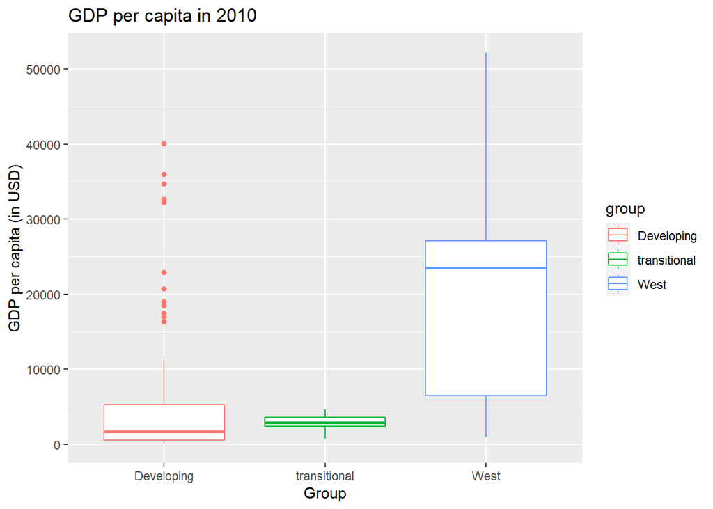

As you can see, this does tell a different story, In the western countries, the range of GDP per capita has increased severely. In this graph, the western countries includes countries from Southern Europe and all of North America. Since some of these countries are undergoing political crises or economic burdens, this would create a large range. However, the developing countries have increased to an extent as well. This could be due to larger investment in these countries as well as industrial activity within the country. Although these countries do have a lower GDP per capita than most western countries, the gap between the ranges of these countries did decrease. Therefore, the preexisting notion does not apply as well to the current situation.

One limitation with this analysis is that it does not take populations correctly into account. Since nations such as India and China have large GDPs and large populations, the GDP per capita measure does not take general wealth for the populace of these countries into account. Additionally, certain countries have massive wealth gaps which again does not take the condition of average citizens into account. This is especially prevalent in transitional countries such as Brazil, India, and Russia.